| National Park Service U.S. Department of the Interior Natural Resource Stewardship and Science |  |
| --- | --- |

# Salt Marsh Elevation Monitoring at Assateague Island National Seashore: 2009 - 2024

Northeast Coastal & Barrier Network (NCBN)

JUN 25 2025

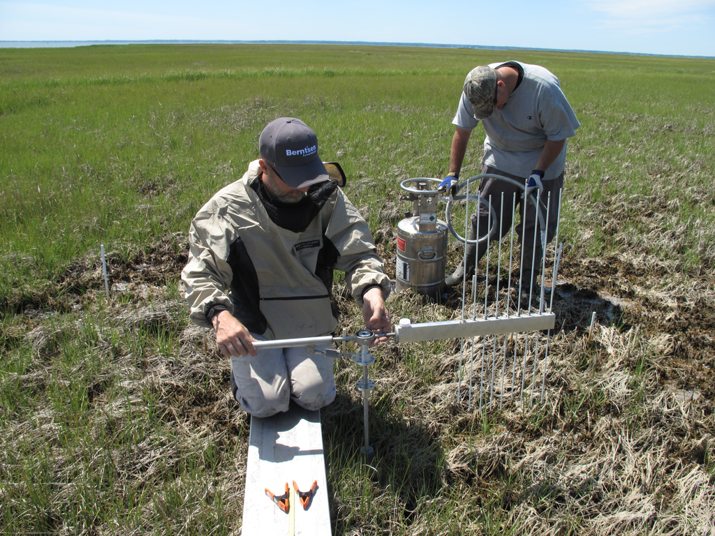

Figure 1: Surface elevation table (SET) monitoring at Assateague Island National Seashore.

# Background

Coastal wetlands exist within a narrow range of elevation which is influenced by local hydrologic conditions. As sea level rises, coastal wetland systems must build elevation at a rate equal to or greater than the rate of sea-level rise to maintain favorable hydrologic conditions for their survival (Figure 2). With global rates of sea-level rise predicted to increase over the coming decades (Church et al. 2010), many more coastal wetlands may become vulnerable to increased inundation. Additionally, certain areas of the coast, such as the mid-Atlantic region, can undergo even greater sea-level rise due to changes in coastal ocean circulation (Sallenger et al. 2012).

The Northeast Coastal & Barrier Inventory and Monitoring Network (NCBN) uses the SET-MH technique (surface elevation table-marker horizon) to monitor elevation change as a vital sign of salt marsh health at Assateague Island National Seashore. In the following sections, we use these data to answer the following questions:

1. What are the elevation characteristics of coastal wetlands in Assateague Island National Seashore? (Figure 2A; Results Section 1)
2. How do local wetland elevation dynamics relate to the local hydrology (e.g., local tidal datums)? (Figure 2C; Results Section 2)
3. Is elevation gain sufficient to keep pace with current and predicted sea level rise? (Figure 2D; Results Section 3)

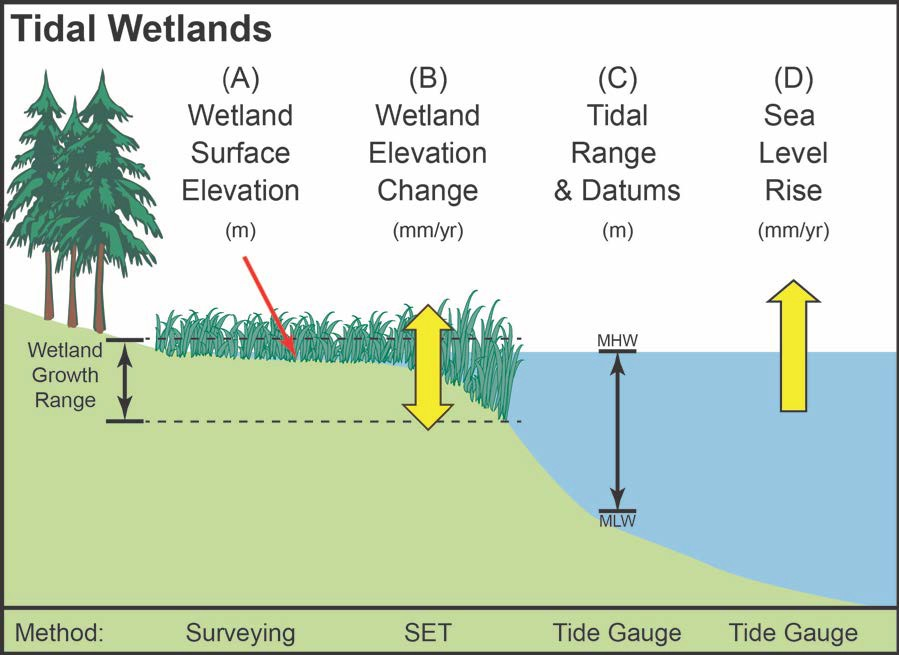

Figure 2: Conceptual diagram showing the relationship among wetland surface elevation (A), tidal datums (C), and their respective rates of change (B and D). Understanding these relationships is important for evaluating the sustainability of a wetland community to sea-level rise.

# Methods

### Protocol

NCBN’s long-term, standardized monitoring protocol for monitoring surface elevation change (Lynch et al. 2015) is implemented semiannually in the spring and fall at Assateague Island National Seashore. Changes in surface elevation are measured using the surface elevation table (SET) technique. The SET is a portable mechanical leveling device providing repeated, high-resolution measurements of elevation change in wetland sediments or shallow water bottoms relative to the depth of a permanent benchmark that has been anchored into the soil until refusal. During measurements, the SET arm is attached to the permanent SET benchmark and extended over the marsh surface at four fixed positions. The SET arm is carefully leveled to rest horizontally to the ground, and each of nine fiberglass pins are lowered through the arm to the soil surface. The height of each pin above the arm is measured on repeated sampling events. Changes in the height of the pins between sampling events are used to quantify soil surface elevation change over time relative to the permanent benchmark (Cahoon et al. 2002a, Cahoon et al. 2002b, Webb et al. 2013).

### Sample Size

All data utilized in this report are available for public use and can be downloaded from the NPS DataStore.

Surface elevation table sites monitored by NCBN within Assateague Island National Seashore.

| Site | SET-MH station count | First reading | Most recent reading | Status |
| --- | --- | --- | --- | --- |
| Marsh 5 (Pope Bay) | 4 | 2009 | 2024 | active |
| Marsh 6 (Pine Tree) | 4 | 2009 | 2024 | active |
| Marsh 8 (Valentines) | 4 | 2009 | 2024 | active |
| Marsh 11 | 4 | 2009 | 2024 | active |
| Pine Tree Study | 3 | 2016 | 2022 | inactive |

### Hydrologic Data, Tidal Datums, & Marsh Flooding Metrics

Water level data were collected at continuous 15 minute intervals from 3 permanent water level recorders (HOBO® 13-Foot Water Level Data Logger, model U20-001-04) installed in the nearest creek/ditch at Marsh 5 (Pope Bay), Marsh 6 (Pine Tree), and Marsh 8 (Valentines). Prior to the calculation of flooding metrics and tidal datums, the raw water level data were first converted to meters NAVD 88 using the absolute elevation of the water loggers derived from on-the-ground RTK surveys as outlined in Curdts 2017. Both the raw water level data and water level data relative to NAVD88 were then uploaded to the NPS AQUARIUS WebPortal for QAQC, certification, and storage. The water level data referenced to NAVD 88 were then used to calculate site-level tidal datums including mean high water (MHW), mean sea-level (MSL), and mean low water (MLW) ([NOAA Tides and Currents Glossary](https://tidesandcurrents.noaa.gov/publications/glossary2.pdf)). In order to calculate metrics of marsh flooding, the water level data referenced to NAVD 88 were compared to ground elevations of the marsh at each site that were collected via RTK surveys (see SOP 6 in Lynch et al. 2015). Percentage time flooded, an indicator of flooding frequency, was calculated as the proportion of days where the water level was above the marsh (Curdts 2017, Stagg et al. 2020).

### Sea-Level Data & Rates of Sea-Level Rise

#### Recent SLR

We estimated a recent rate of relative sea-level rise using a linear regression applied to the monthly mean sea-level data with the average seasonal cycle removed by subsetting the data from the Ocean City, MD gauge for the most recent tidal epoch between 2001 to 2019 (Moon et al. 2022).

#### Future SLR

We estimated future projected relative sea-level rise rates using the five alternative SLR scenarios produced by Sweet et al. 2022 for the 5th National Climate Assessment. The Low, Intermediate-Low, Intermediate, Intermediate-High, and High SLR scenarios correspond respectively to global mean sea level increases of 0.3 m, 0.5 m, 1.0 m, 1.5 m, and 2.0 m by 2100. To approximate the RSLR rate by 2100 under each of the five scenarios, we used the data provided by Sweet et al. (2022) to estimate future RSLR rates for the 2090-2100 decade from the Ocean City, MD RSLR projections (Chivoiu et al. 2020, Osland et al. 2024).

[interactive chart not shown]

Figure 3: Individual SET stations within Assateague Island National Seashore. Click on the points to see the site and station labels.

# Results

### 1. What are the elevation characteristics of coastal wetlands at Assateague Island National Seashore?

Site-level rates of surface elevation change within Assateague Island National Seashore. Rates of surface elevation change labeled with * are significantly different from 0.

[output not shown]

[interactive chart not shown]

Figure 4: Site-level surface elevation change at Assateague Island National Seashore. Rates of surface elevation change (SEC) are shown in panel labels. Hover the mouse over a data point to see the cumulative surface elevation change value on a specific date, or click and drag over a specific time to zoom in. Double click to zoom back out

### 2. How does local hydrology relate to wetland elevation? How do local wetland elevation dynamics relate to the local hydrology (e.g., local tidal datums)?

Site-level flooding metrics for Assateague Island National Seashore.

| Site | Record length | Marsh elevation (m NAVD88) | Average minimum flood depth (m) | Time flooded (%) | # Flood events | Longest flood event |
| --- | --- | --- | --- | --- | --- | --- |
| Marsh 5 (Pope Bay) | Mar 2012 - May 2025 | 0.1450 | 0.0125 | 27 | 3834 | 56 days (Aug - Oct 2020) |
| Marsh 6 (Pine Tree) | Mar 2012 - May 2025 | 0.1325 | 0.0084 | 29 | 5165 | 17 days (Sep - Oct 2024) |
| Marsh 8 (Valentines) | Mar 2012 - May 2025 | 0.2000 | 0.0087 | 12 | 1760 | 10 days (Nov 2024) |

### 3. Is elevation gain sufficient to keep pace with current and predicted sea-level rise?

#### Comparisons to current sea-level rise

Additionally, using the sea-level data from the nearby NOAA tide gauge, we calculated a recent rate of relative sea-level rise of 7.26 mm/yr (± 1.16) for Assateague Island National Seashore over the most recent tidal epoch (2001-2019). None of the sites at Assateague Island National Seashore were building elevation at a rate close to or greater than the relative recent rate of sea-level rise (Figure 5).

[interactive chart not shown]

Figure 5: Site-level surface elevation change at Assateague Island National Seashore compared to relative long-term and recent rates of sea-level rise. … Hover the mouse over a data point to see the cumulative surface elevation change value on a specific date, or click and drag over a specific time to zoom in. Double click to zoom back out

#### Comparisons to future sea-level rise

Based on the calculations provided in Sweet et al. 2022, future predicted rates of relative sea-level rise by 2100 for Assateague Island National Seashore ranged from a low of 6.00 mm/yr for the “low” sea-level rise scenario to a high of 38.00 mm/yr for the “high” sea-level rise scenario (Table 1).

Table 1: Predicted future sea-level rise by 2100 for Assateague Island National Seashore. Future predicted sea-level and rates of sea-level rise were based on calculations for the nearest NOAA tide gauge provided in Sweet et al. 2022 for the 5th National Climate Assessment .

[output not shown]

# References

[Cahoon, D.R., Lynch, J.C., Hensel, P., Boumans, R., Perez, B.C., Segura, B. and Day Jr, J.W., 2002. High-precision measurements of wetland sediment elevation: I. Recent improvements to the sedimentation-erosion table. Journal of Sedimentary Research, 72(5), pp.730-733.](https://doi.org/10.1306/020702720730)  
[Cahoon, D.R., Lynch, J.C., Perez, B.C., Segura, B., Holland, R.D., Stelly, C., Stephenson, G. and Hensel, P., 2002. High-precision measurements of wetland sediment elevation: II. The rod surface elevation table. Journal of Sedimentary Research, 72(5), pp.734-739.](https://doi.org/10.1306/020702720734)  
[Chivoiu, B., Osland, M.J., Collini, R., Martin, S., Tirpak, J., and Wilson, B., 2020, Local sea level rise information sheets for Texas, Louisiana, Mississippi, Alabama and Florida: Northern Gulf of Mexico Sentinel Site Cooperative, U.S. Geological Survey and U.S. Fish and Wildlife Service: Mississippi-Alabama Sea Grant Consortium, https://placeslr.org/our-products/federally-managed-lands-two-pagers/.](https://placeslr.org/our-products/federally-managed-lands-two-pagers/)  
[Church, J.A, P.L. Woodworth, T. Aarup, and W.S. Wilson. 2010. Understanding sea level rise and variability. Blackwell, New York, NY.](https://doi.org/10.1002/9781444323276)  
[Curdts LT. 2017. Continuous water level data collection and management using Onset HOBO® data loggers: A Northeast Coastal and Barrier Network methods document. Natural Resource Report. NPS/NCBN/NRR—2017/1370. National Park Service. Fort Collins, Colorado https://irma.nps.gov/DataStore/Reference/Profile/2237862.](https://irma.nps.gov/DataStore/Reference/Profile/2237862)  
[Feher, L.C., Osland, M.J., Johnson, D.J., Grace, J.B., Guntenspergen, G.R., Stewart, D.R., Coronado-Molina, C. and Sklar, F.H., 2024. Nonlinear patterns of surface elevation change in coastal wetlands: The value of generalized additive models for quantifying rates of change. Estuaries and Coasts, 47(7), pp.1893-1902.](https://doi.org/10.1007/s12237-023-01268-w)  
[Lynch, J.C., P. Hensel, and D.R. Cahoon. 2015. The surface elevation table and marker horizon technique: A protocol for monitoring wetland elevation dynamics. Natural Resource Report NPS/NCBN/NRR—2015/1078. National Park Service, Fort Collins, Colorado.](https://irma.nps.gov/DataStore/Reference/Profile/2225005)  
[Lynch, J.C., N. Winn, K. Kovalenko, and G. Guntenspergen. 2024. Comparing wetland elevation change using a surface elevation table, digital level, and total station. Estuaries and Coasts, 47, 2071-2079.](https://doi.org/10.1007/s12237-023-01263-1)  
[Moon, J.A., Feher, L.C., Lane, T.C., Vervaeke, W.C., Osland, M.J., Head, D.M., Chivoiu, B.C., Stewart, D.R., Johnson, D.J., Grace, J.B. and Metzger, K.L., 2022. Surface elevation change dynamics in coastal marshes along the Northwestern Gulf of Mexico: Anticipating effects of rising sea-level and intensifying hurricanes. Wetlands, 42(5), p.49.](https://doi.org/10.1007/s13157-022-01565-3)  
[Osland, M.J., Chivoiu, B., Grace, J.B., Enwright, N.M., Guntenspergen, G.R., Buffington, K.J., Thorne, K.M., Carr, J.A., Sweet, W.V. and Couvillion, B.R., 2024. Rising seas could cross thresholds for initiating coastal wetland drowning within decades across much of the United States. Communications Earth & Environment, 5(1), p.372.](https://doi.org/10.1038/s43247-024-01537-x)  
[Russell, B. T., Cressman, K. A., Schmit, J. P., Shull, S., Rybczyk, J. M., & Frost, D. L. (2022). How should surface elevation table data be analyzed? A comparison of several commonly used analysis methods and one newly proposed approach. Environmental and Ecological Statistics, 29(2), 359-391. https://doi.org/10.1007/s10651-021-00524-1](https://doi.org/10.1007/s10651-021-00524-1)  
[Sallenger, A., Doran, K. & Howd, P. Hotspot of accelerated sea-level rise on the Atlantic coast of North America. Nature Clim Change 2, 884–888 (2012). https://doi.org/10.1038/nclimate1597](https://doi.org/10.1038/nclimate1597)  
[Camille L Stagg, Michael J Osland, Jena A Moon, Courtney T Hall, Laura C Feher, William R Jones, Brady R Couvillion, Stephen B Hartley, William C Vervaeke, Quantifying hydrologic controls on local- and landscape-scale indicators of coastal wetland loss, Annals of Botany, Volume 125, Issue 2, 23 January 2020, Pages 365–376, https://doi.org/10.1093/aob/mcz144.](https://doi.org/10.1093/aob/mcz144)  
[Sweet, W.V., B.D. Hamlington, R.E. Kopp, C.P. Weaver, P.L. Barnard, D. Bekaert, W. Brooks, M. Craghan, G. Dusek, T. Frederikse, G. Garner, A.S. Genz, J.P. Krasting, E. Larour, D. Marcy, J.J. Marra, J. Obeysekera, M. Osler, M. Pendleton, D. Roman, L. Schmied, W. Veatch, K.D. White, and C. Zuzak. 2022. Global and Regional Sea Level Rise Scenarios for the United States: Updated Mean Projections and Extreme Water Level Probabilities Along U.S. Coastlines. NOAA Technical Report NOS 01. National Oceanic and Atmospheric Administration, National Ocean Service, Silver Spring, MD, 111 pp.](https://oceanservice.noaa.gov/hazards/sealevelrise/noaa-nos-techrpt01-global-regional-SLR-scenarios-US.pdf)  
[Webb, E.L., Friess, D.A., Krauss, K.W., Cahoon, D.R., Guntenspergen, G.R. and Phelps, J., 2013. A global standard for monitoring coastal wetland vulnerability to accelerated sea-level rise. Nature Climate Change, 3(5), pp.458-465.](https://doi.org/10.1038/nclimate1756)

## Contact Information

Katie Button, Biologist & Protocol Lead  
Kaitlyn_Button@nps.gov  
Laura Feher, Biologist & NCBN Data Scientist  
Laura_Feher@nps.gov  
[Vital Signs: Northeastern Coastal & Barrier Inventory and Monitoring Network](https://www.nps.gov/im/ncbn/what-we-monitor.htm)  
[Reports & Publications (U.S. National Park Service) (nps.gov)](https://www.nps.gov/im/ncbn/reports-publications-data.htm)